# Unsupervised Analysis of Transcriptomic Differences - Plotting

Chante Bethell for CCDL 2019

This notebook is the second part of an analysis that demonstrate samples in the PBTA cluster by cancer type using dimensionality reduction techniques, [Principal Component Analysis](https://www.rdocumentation.org/packages/stats/versions/3.6.0/topics/prcomp) (PCA), [t-Distributed Stochastic Neighbor Embedding](https://cran.r-project.org/web/packages/Rtsne/Rtsne.pdf) (t-SNE), and [Uniform Manifold Approximation and Projection](https://cran.r-project.org/web/packages/umap/vignettes/umap.html) (UMAP).

This notebook focuses on plotting the dimension reduction score data.

It addresses [issue #9](https://github.com/AlexsLemonade/OpenPBTA-analysis/issues/9) in the Open-PBTA analysis repository.

## Summary of Findings:

Upon plotting the dimension reduction scores produced by each of the three unique techniques mentioned above, it was noticed that there may be batch effects present.

- The `RNA_library` variable within the metadata may be useful in correcting said batch effects as suggested by the strategy selection plots for both sets of expression data.

## Output Files:

- `analyses/transcriptomic-dimension-reduction/plots/meta_grid_kallisto_type.pdf`
- `analyses/transcriptomic-dimension-reduction/plots/meta_grid_kallisto_strategy.pdf`
- `analyses/transcriptomic-dimension-reduction/plots/meta_grid_rsem_type.pdf`
- `analyses/transcriptomic-dimension-reduction/plots/meta_grid_rsem_strategy.pdf`

# Usage

This script is intended to be run via the command line from the top directory of the repository as follows:

```
Rscript -e "rmarkdown::render('analyses/transcriptomic-dimension-reduction/02-transcriptomic-analysis-plotting.Rmd', clean = TRUE)"
```

# Set Up

Assign functions.

```r
# Function to plot
plot_dimension_reduction <-
  function(aligned_scores_df, point_color, score1, score2) {
    # Given a data.frame that contains the scores of a dimension reduction
    # analysis and the information we want from the metadata, make a scatterplot.
    #
    # Args:
    #   dimension_reduction_df: data.frame containing dimension reduction scores,
    #                           and relative information from the metadata
    #   point_color: the variable whose information will be used to color
    #                the points on the plot
    #   score1: the column number of the first dimension reduction score that we
    #           want to plot
    #   score2: the column number of the second dimension reduction score that
    #           we want to plot
    #
    # Returns:
    #   dimension_reduction_plot: the plot representing the dimension reduction
    #                             scores in the given data.frame, using the values
    #                             in `point_color` as symbols to color the points

    # transform the strings in `point_color` into symbols for plotting
    color_sym <- rlang::sym(point_color)

    dimension_reduction_plot <- ggplot2::ggplot(
      aligned_scores_df,
      ggplot2::aes(
        x = aligned_scores_df[, score1],
        y = aligned_scores_df[, score2],
        color = !!color_sym
      )
    ) +
      ggplot2::geom_point()

    return(dimension_reduction_plot)

  }
```

Assign name of the output directories.

```r
# Assign names of output directories
results_dir <- "results"
plots_dir <- "plots"

# Create directory to hold the output.
if (!dir.exists(plots_dir)) {
  dir.create(plots_dir)
}
```

Read in the tsv files containing the dimension reduction scores aligned with the metadata, which were produced in `01-transcriptomic-analysis-prep.R`.

```r
rsem_pca_aligned_df <-
  data.frame(readr::read_tsv(file.path(
    results_dir, "rsem_pca_scores_aligned.tsv"
  )))
rsem_tsne_aligned_df <-
  data.frame(readr::read_tsv(file.path(
    results_dir, "rsem_tsne_scores_aligned.tsv"
  )))
rsem_umap_aligned_df <-
  data.frame(readr::read_tsv(file.path(
    results_dir, "rsem_umap_scores_aligned.tsv"
  )))

kallisto_pca_aligned_df <-
  data.frame(readr::read_tsv(file.path(
    results_dir, "kallisto_pca_scores_aligned.tsv"
  )))
kallisto_tsne_aligned_df <-
  data.frame(readr::read_tsv(file.path(
    results_dir, "kallisto_tsne_scores_aligned.tsv"
  )))
kallisto_umap_aligned_df <-
  data.frame(readr::read_tsv(file.path(
    results_dir, "kallisto_umap_scores_aligned.tsv"
  )))
```

# Plot

## RSEM Plots Grid

The grid of plots below shows the dimension reductions scores for the RSEM expression data, colored by tumor type and selection strategy. These plots seem to suggest the presence of batch effects, which is likely due to the need for normalization across the two batches of RNA-Seq preparation (poly-A selection versus stranded(ribosomal depletion)). This can be further determined using the `RNA_library` column of the metadata to attempt to correct batch effects as suggested by the selection strategy grid of plots.

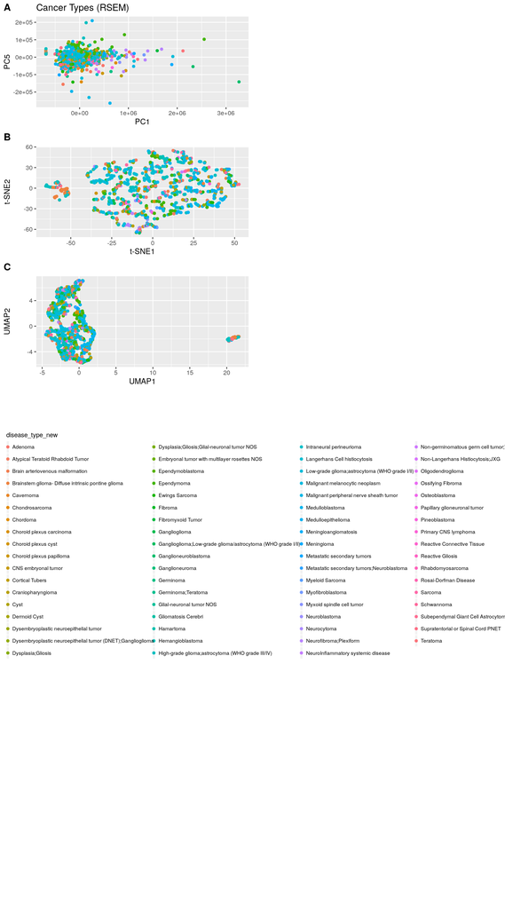

```r
# Run the `plot_dimension_reduction` function to plot each set of dimension
# reduction scores using `disease_type_new` to color points
rsem_pca_plot_type <-
  plot_dimension_reduction(rsem_pca_aligned_df, "disease_type_new", 1, 5)
rsem_tsne_plot_type <-
  plot_dimension_reduction(rsem_tsne_aligned_df, "disease_type_new", 1, 2)
rsem_umap_plot_type <-
  plot_dimension_reduction(rsem_umap_aligned_df, "disease_type_new", 1, 2)

# Run the `plot_dimension_reduction` function to plot each set of dimension
# reduction scores using `RNA_library` to color points
rsem_pca_plot_strategy <-
  plot_dimension_reduction(rsem_pca_aligned_df, "RNA_library", 1, 5)
rsem_tsne_plot_strategy <-
  plot_dimension_reduction(rsem_tsne_aligned_df, "RNA_library", 1, 2)
rsem_umap_plot_strategy <-
  plot_dimension_reduction(rsem_umap_aligned_df, "RNA_library", 1, 2)

# Extract the legend from one of the cancer type plots
legend_a <- cowplot::get_legend(
  rsem_umap_plot_type +
    ggplot2::theme(
      legend.direction = "vertical",
      legend.position = c(0.05, 0.40),
      legend.key.width = ggplot2::unit(0.1, "cm"),
      text = ggplot2::element_text(size = 9)
    )
)

# Extract the legend from one of the selection strategy plots
legend_b <- cowplot::get_legend(
  rsem_umap_plot_strategy +
    ggplot2::theme(
      legend.direction = "vertical",
      legend.key.width = ggplot2::unit(0.1, "cm"),
      text = ggplot2::element_text(size = 15)
    )
)

# Plot grid with RSEM data colored by cancer type
rsem_grid_type <- cowplot::plot_grid(
  rsem_pca_plot_type + ggplot2::theme(legend.position = "none") +
    ggplot2::labs(x = "PC1", y = "PC5") +
    ggplot2::ggtitle("Cancer Types (RSEM)"),
  rsem_tsne_plot_type + ggplot2::theme(legend.position = "none") +
    ggplot2::labs(x = "t-SNE1", y = "t-SNE2"),
  rsem_umap_plot_type + ggplot2::theme(legend.position = "none") +
    ggplot2::labs(x = "UMAP1", y = "UMAP2"),
  labels = "AUTO",
  align = "vh",
  axis = "b",
  ncol = 1,
  nrow = 7
)

# Plot grid with RSEM data colored by selection strategy
rsem_grid_strategy <- cowplot::plot_grid(
  rsem_pca_plot_strategy + ggplot2::theme(legend.position = "none") +
    ggplot2::labs(x = "PC1", y = "PC5") +
    ggplot2::ggtitle("Selection Strategy (RSEM)"),
  rsem_tsne_plot_strategy + ggplot2::theme(legend.position = "none") +
    ggplot2::labs(x = "t-SNE1", y = "t-SNE2"),
  rsem_umap_plot_strategy + ggplot2::theme(legend.position = "none") +
    ggplot2::labs(x = "UMAP1", y = "UMAP2"),
  labels = "AUTO",
  align = "vh",
  axis = "b",
  ncol = 1,
  nrow = 5
)

# Add the appropriate legends to the cowplots
rsem_grid_type <-
  cowplot::plot_grid(rsem_grid_type, legend_a, rel_heights = c(2, .2))

rsem_grid_strategy <-
  cowplot::plot_grid(rsem_grid_strategy, legend_b, rel_heights = c(2, 2))

# Save cancer type plot grid
ggplot2::ggsave(
   file.path("plots", "meta_grid_rsem_type.pdf"),
   rsem_grid_type,
   width = 12,
   height = 15
 )

 # Save selection strategy plot grid
 ggplot2::ggsave(
   file.path("plots", "meta_grid_rsem_strategy.pdf"),
   rsem_grid_strategy,
   width = 12,
   height = 15
 )

# Display the plot grid across cancer types
rsem_grid_type
```

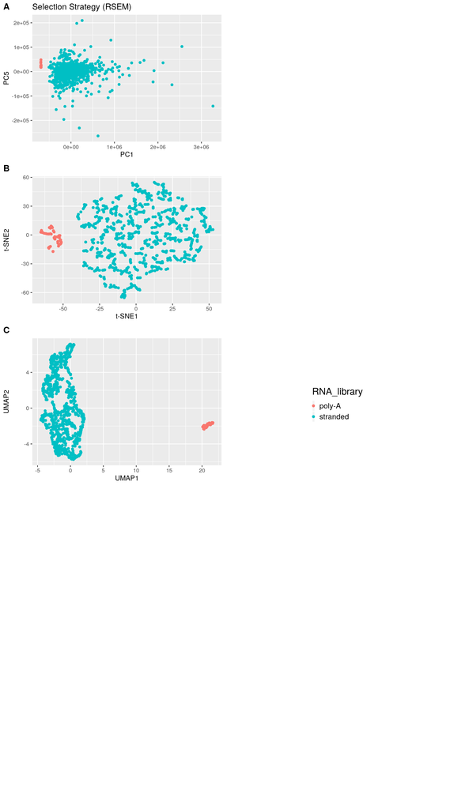

```r
# Display the plot grid across selection strategy
rsem_grid_strategy
```

## Kallisto Plots Grid

The grid of plots below shows the dimension reductions scores for the Kallisto expression data, colored by tumor type and selection strategy. These plots seem to suggest the presence of batch effects, which is likely due to the need for normalization across the two batches of RNA-Seq preparation (poly-A selection versus stranded(ribosomal depletion)). This can be further determined using the `RNA_library` column of the metadata to attempt to correct batch effects as suggested by the selection strategy grid of plots.

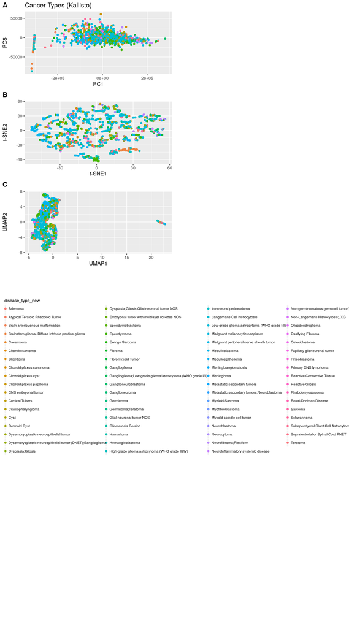

```r
# Run the `plot_dimension_reduction` function to plot each set of dimension
# reduction scores using `disease_type_new` to color points
kallisto_pca_plot_type <-
  plot_dimension_reduction(kallisto_pca_aligned_df, "disease_type_new", 1, 5)
kallisto_tsne_plot_type <-
  plot_dimension_reduction(kallisto_tsne_aligned_df, "disease_type_new", 1, 2)
kallisto_umap_plot_type <-
  plot_dimension_reduction(kallisto_umap_aligned_df, "disease_type_new", 1, 2)

# Run the `plot_dimension_reduction` function to plot each set of dimension
# reduction scores using `RNA_library` to color points
kallisto_pca_plot_strategy <-
  plot_dimension_reduction(kallisto_pca_aligned_df, "RNA_library", 1, 5)
kallisto_tsne_plot_strategy <-
  plot_dimension_reduction(kallisto_tsne_aligned_df, "RNA_library", 1, 2)
kallisto_umap_plot_strategy <-
  plot_dimension_reduction(kallisto_umap_aligned_df, "RNA_library", 1, 2)

# Extract the legend from one of the cancer type plots
legend_a <- cowplot::get_legend(
  kallisto_umap_plot_type +
    ggplot2::theme(
      legend.direction = "vertical",
      legend.position = c(0.05, 0.40),
      legend.key.width = ggplot2::unit(0.1, "cm"),
      text = ggplot2::element_text(size = 9)
    )
)

# Extract the legend from one of the selection strategy plots
legend_b <- cowplot::get_legend(
  kallisto_umap_plot_strategy +
    ggplot2::theme(
      legend.direction = "vertical",
      legend.key.width = ggplot2::unit(0.1, "cm"),
      text = ggplot2::element_text(size = 15)
    )
)

# Plot grid with Kallisto data colored by cancer type
kallisto_grid_type <- cowplot::plot_grid(
  kallisto_pca_plot_type + ggplot2::theme(legend.position = "none") +
    ggplot2::labs(x = "PC1", y = "PC5") +
    ggplot2::ggtitle("Cancer Types (Kallisto)"),
  kallisto_tsne_plot_type + ggplot2::theme(legend.position = "none") +
    ggplot2::labs(x = "t-SNE1", y = "t-SNE2"),
  kallisto_umap_plot_type + ggplot2::theme(legend.position = "none") +
    ggplot2::labs(x = "UMAP1", y = "UMAP2"),
  labels = "AUTO",
  align = "vh",
  axis = "b",
  ncol = 1,
  nrow = 7
)

# Plot grid with Kallisto data colored by selection strategy
kallisto_grid_strategy <- cowplot::plot_grid(
  kallisto_pca_plot_strategy + ggplot2::theme(legend.position = "none") +
    ggplot2::labs(x = "PC1", y = "PC5") +
    ggplot2::ggtitle("Selection Strategy (Kallisto)"),
  kallisto_tsne_plot_strategy + ggplot2::theme(legend.position = "none") +
    ggplot2::labs(x = "t-SNE1", y = "t-SNE2"),
  kallisto_umap_plot_strategy + ggplot2::theme(legend.position = "none") +
    ggplot2::labs(x = "UMAP1", y = "UMAP2"),
  labels = "AUTO",
  align = "vh",
  axis = "b",
  ncol = 1,
  nrow = 5
)

# Add the appropriate legends to the cowplots
kallisto_grid_type <-
  cowplot::plot_grid(kallisto_grid_type, legend_a, rel_heights = c(2, .2))

kallisto_grid_strategy <-
  cowplot::plot_grid(kallisto_grid_strategy, legend_b, rel_heights = c(2, 2))

 # Save cancer type plot grid
 ggplot2::ggsave(
   file.path("plots", "meta_grid_kallisto_type.pdf"),
   kallisto_grid_type,
   width = 12,
   height = 15
 )

 # Save selection strategy plot grid
 ggplot2::ggsave(
   file.path("plots", "meta_grid_kallisto_strategy.pdf"),
   kallisto_grid_strategy,
   width = 12,
   height = 15
 )

# Display the plot grid across cancer types
kallisto_grid_type
```

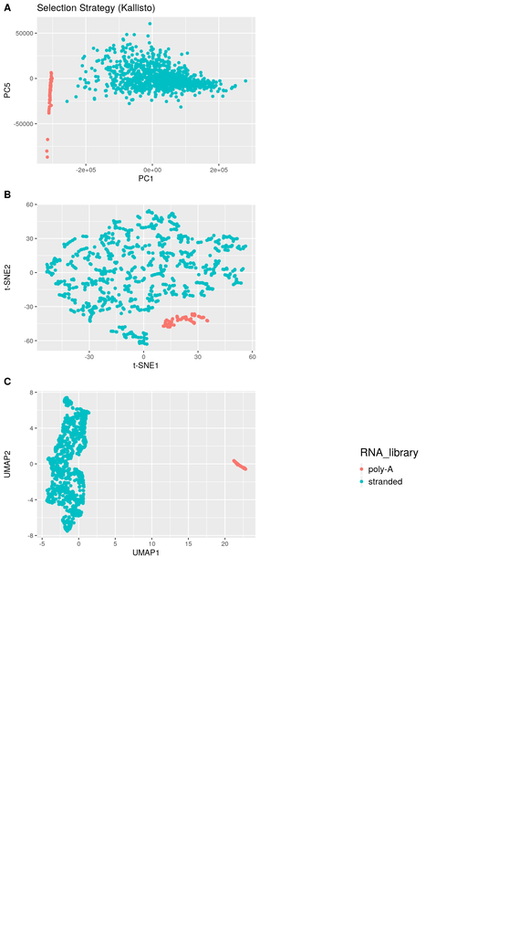

```r
# Display the plot grid across selection strategy
kallisto_grid_strategy
```